# Code for cell fate annotation

This notebook reports the steps to annotate the cells for Dataset A and B for the article and to obtain the related figures for what concerns:  
- the UMAP of the two datasets with the annotation and corresponding marker genes;  
- the UMAP of the two datasets with the family label;  
- the UMAP of the two datasets with the times of division.

Please refer to the article for more details.

## Libraries and sources

Load libraries

```r
library(tidyverse)
library(Seurat)
library(matrixStats)
library(pals)
library(patchwork)
```

Set working directory and load routines You can set your own path where the file is located, for example:  
setwd(“C:\Users\UserName\Documents\Transcriptomics”)

```r
script_path <- rstudioapi::getActiveDocumentContext()$path
setwd(dirname(script_path))
source("repository_functions.R")
```

## Parameters

Clustering parameters

```r
ndims <- 30
n_neigh <- 15
k_param <- 8
min_dist <- 0.3
res_1 <- 0.6
res_2 <- 1
res_3 <- 0.4
```

Plotting parameters

```r
colors_fourclusters <- c("#0047AB", "#7CAE00", "#40E0D0", "#C70039")

# theme for saving figures
default_theme <- theme(plot.title = element_text(hjust =0.5, size=26), axis.line = element_line(size = 2),axis.text = element_text(size = 24),axis.title = element_text(size = 26),legend.text = element_text(size = 22))
```

Assign the nomenclature to use in the figures

```r
U_name <- "CD34+CD38-/HPC" # MPP/HPC
M_name <- "MyP" # Myeloid Progenitor
EM_name <- "EryP/MkP" # ErythroMegakaryocytes Progenitor
G_name <- "GraP" # Granulocytic progenitor
nomenclature_levels <- c("CD34+CD38-/HPC", "MyP", "GraP", "EryP/MkP")

# gene expression markers
gene_markers <- c("MPO", "ELANE", "AZU1", "ITGA2B", "HBB")
```

## Load datasets

Load datasetA

```r
output_A<-summary_load_v2("../Datasets/dataset1_raw_matrix.csv",
                          "../Datasets/dataset1_metadata_input.csv")
datasetA<-output_A$obj
datasetA_metadata<-output_A$nm_cells
```

Load datasetB

```r
output_B<-summary_load_v2("../Datasets/dataset3_raw_matrix.csv",
                          "../Datasets/dataset3_metadata_input.csv")
datasetB<-output_B$obj
datasetB_metadata<-output_B$nm_cell
```

Create Seurat objects

```r
expA.realdata <-seurat_object_wt_metadata(datasetA, datasetA_metadata)
expB.realdata <-seurat_object_wt_metadata(datasetB, datasetB_metadata)
```

## Clustering

SCT normalization Obtain cluster with two different resolutions. DatasetA

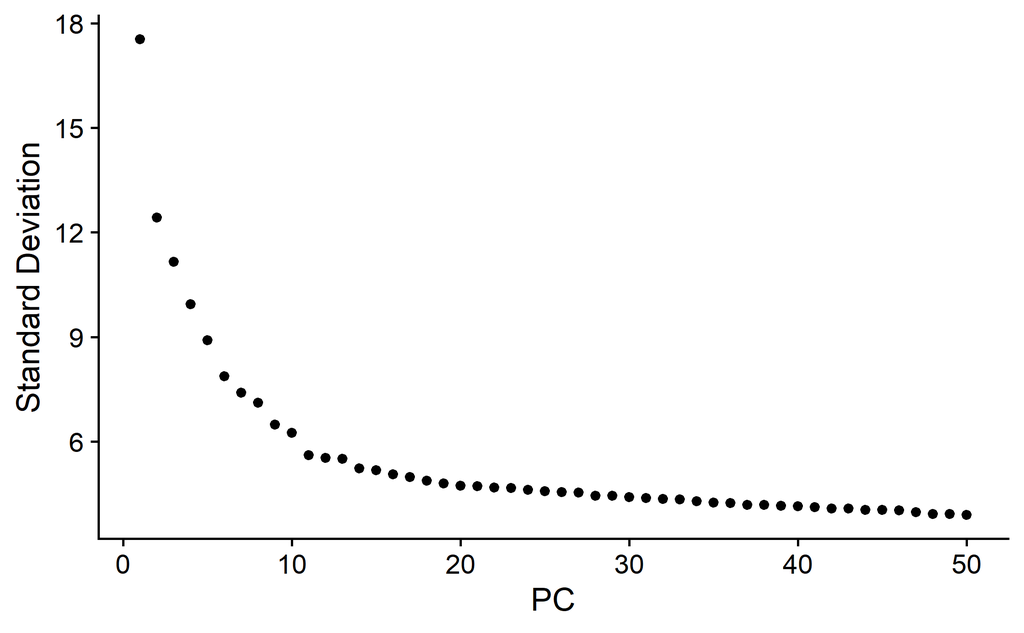

```r
expA.realdata <- run_clustering(expA.realdata, ndims,
n_neigh, k_param, min_dist, res_1, res_2, reduction_name_pca = 'pca_expA_sct', reduction_name_umap='umap_expA_sct')
```

DatasetB

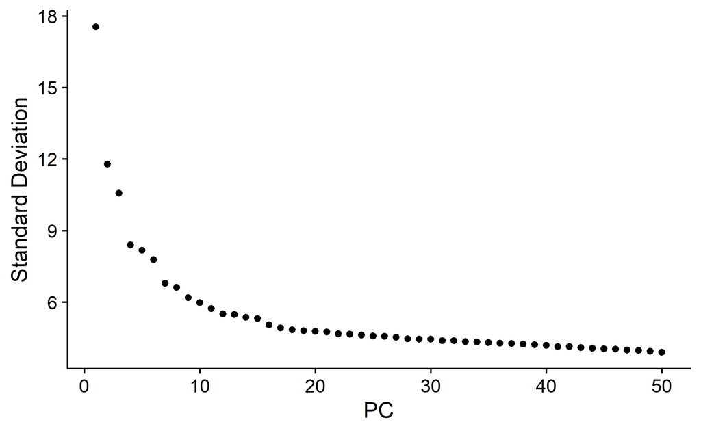

```r
expB.realdata <- run_clustering(expB.realdata, ndims,
n_neigh, k_param, min_dist, res_3, res_2, reduction_name_pca = 'pca_expB_sct',reduction_name_umap='umap_expB_sct')
```

### Three groups clustering

Assign name to clusters This annotation is based on marker genes. Please refer to the section “Marker genes”.  
DatasetA

```r
expA.realdata$predicted.celltype <- NA
expA.realdata$predicted.celltype <- ifelse(expA.realdata$SCT_snn_res.1 == 2, M_name, expA.realdata$predicted.celltype)
expA.realdata$predicted.celltype <- ifelse(expA.realdata$SCT_snn_res.1 == 1, EM_name, expA.realdata$predicted.celltype)
expA.realdata$predicted.celltype <- ifelse(expA.realdata$SCT_snn_res.1 == 0, U_name, expA.realdata$predicted.celltype)
Idents(expA.realdata) <- expA.realdata$predicted.celltype
expA.realdata$cn <- rownames(expA.realdata@meta.data)
```

DatasetB

```r
expB.realdata$predicted.celltype <- NA
expB.realdata$predicted.celltype <- ifelse(expB.realdata$SCT_snn_res.1 == 1, M_name, expB.realdata$predicted.celltype)
expB.realdata$predicted.celltype <- ifelse(expB.realdata$SCT_snn_res.1 == 2, EM_name, expB.realdata$predicted.celltype)
expB.realdata$predicted.celltype <- ifelse(expB.realdata$SCT_snn_res.1 == 0, U_name, expB.realdata$predicted.celltype)
Idents(expB.realdata) <- expB.realdata$predicted.celltype
expB.realdata$cn <- rownames(expB.realdata@meta.data)
```

### Four groups clustering

DatasetA

```r
output_elane_dtA <- find_elane(expA.realdata, "RNA", 0)
ELANE_dtA <- output_elane_dtA$elane_cells
expA.realdata$predicted.celltype <- ifelse(expA.realdata$cn %in% ELANE_dtA, G_name, expA.realdata$predicted.celltype)
Idents(expA.realdata) <- expA.realdata$predicted.celltype
Idents(expA.realdata) <- ordered(Idents(expA.realdata), levels=nomenclature_levels)

plotC<-DimPlot(expA.realdata, reduction='umap_expA_sct', cols=colors_fourclusters, pt.size=3, order=T) + ggtitle("Dataset A") + default_theme
```

|  | t | l | b | r |
| --- | --- | --- | --- | --- |
| 1: | 1 | 1 | 1 | 1 |

```r
NA
```

DatasetB

```r
output_elane_dtB <- find_elane(expB.realdata, "RNA", 0)
ELANE_dtB <- output_elane_dtB$elane_cells
expB.realdata$predicted.celltype <- ifelse(expB.realdata$cn %in% ELANE_dtB, G_name, expB.realdata$predicted.celltype)
Idents(expB.realdata) <- expB.realdata$predicted.celltype
Idents(expB.realdata) <- ordered(Idents(expB.realdata), levels=nomenclature_levels)

plotD<-DimPlot(expB.realdata, cols=colors_fourclusters, reduction='umap_expB_sct', pt.size=3, order=T) + ggtitle("Dataset B") + default_theme
```

|  | t | l | b | r |
| --- | --- | --- | --- | --- |
| 1: | 1 | 1 | 1 | 1 |

Plots

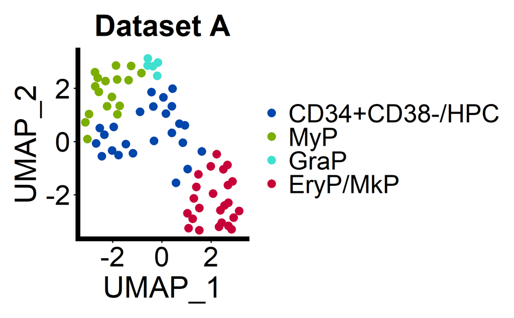

```r
plotC
```

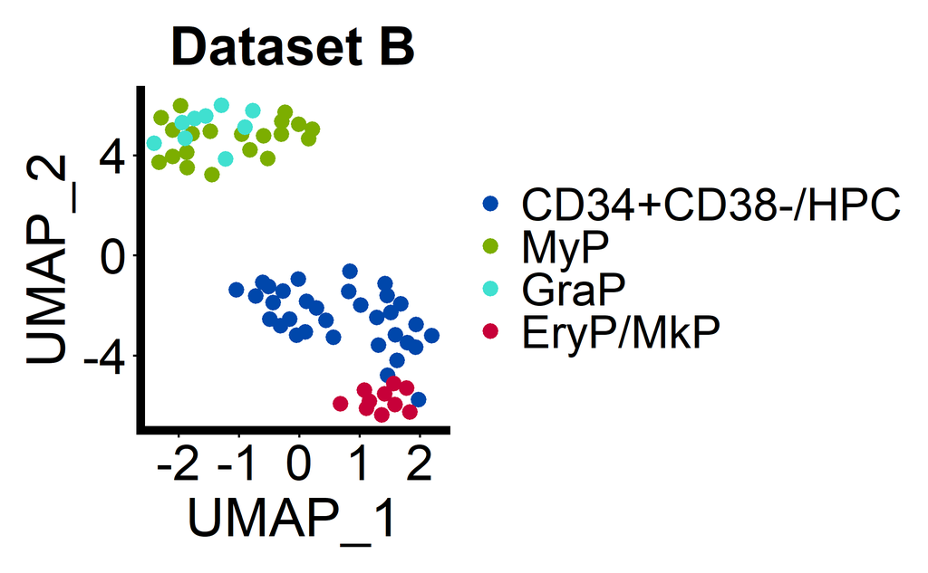

```r
plotD
```

```r
#plotC|plotD
```

Save images

```r
ggsave(plotC,
       filename = "../Figures/Fig_UMAP_datasetA.svg",
       device = "svg",
       height = 6, width = 8, units = "in")
ggsave(plotD,
       filename = "../Figures/Fig_UMAP_datasetB.svg",
       device = "svg",
       height = 6, width = 8, units = "in")
```

Assign new metadata with four groups clustering annotation to run MIIC

```r
stopifnot(identical(colnames(datasetA_metadata), colnames(datasetB_metadata)))

vars_tosave <- datasetA_metadata %>%
  colnames %>% union("predicted.celltype")

vars_tosave <- union("X", vars_tosave)
expA.realdata$X <- rownames(expA.realdata@meta.data)
expB.realdata$X <- rownames(expB.realdata@meta.data)
datasetA_metadata_cluster_ann <- expA.realdata@meta.data[, vars_tosave]
datasetB_metadata_cluster_ann <- expB.realdata@meta.data[, vars_tosave]
```

Save files

```r
write.csv(datasetA_metadata_cluster_ann,sprintf("../Output/dataset1_metadata_step1.csv"), row.names=FALSE)
write.csv(datasetB_metadata_cluster_ann,sprintf("../Output/dataset3_metadata_step1.csv"), row.names=FALSE)
```

## Markers genes

For plotting, the log-normalized RNA counts are shown.

```r
DefaultAssay(expA.realdata) <- "RNA"
expA.realdata <- NormalizeData(expA.realdata)
DefaultAssay(expB.realdata) <- "RNA"
expB.realdata <- NormalizeData(expB.realdata)
```

Feature plots

```r
apply_theme <- function(p) {
  p + theme(
    plot.title = element_text(hjust = 0.5, face = "bold",   size =26),
    axis.line = element_line(size = 2),
    axis.text = element_text(size = 24),
    axis.title = element_text(size = 26),
    legend.text = element_text(size = 16))
}

fp_dtA <- FeaturePlot(expA.realdata, gene_markers, combine=FALSE)
customized_plots_dtA <- lapply(fp_dtA, apply_theme)
fp_dtA <- wrap_plots(customized_plots_dtA, nrow=3, ncol=2) +
  plot_annotation(title = "Dataset A", theme = theme(plot.title = element_text(hjust = 0.5, face='bold',size = 26)))
```

|  | t | l | b | r |
| --- | --- | --- | --- | --- |
| 1: | 1 | 1 | 1 | 1 |
| 2: | 2 | 1 | 2 | 1 |
| 3: | 1 | 2 | 1 | 2 |
| 4: | 2 | 2 | 2 | 2 |
| 5: | 1 | 3 | 1 | 3 |
| 6: | 2 | 3 | 2 | 3 |

```r
fp_dtB<- FeaturePlot(expB.realdata, gene_markers,
combine=FALSE)
customized_plots_dtB <- lapply(fp_dtB, apply_theme)
fp_dtB <- wrap_plots(customized_plots_dtB, nrow=2, ncol=2) +
  plot_annotation(title = "Dataset B", theme = theme(plot.title = element_text(hjust = 0.5, face='bold',size = 26)))
```

|  | t | l | b | r |
| --- | --- | --- | --- | --- |
| 1: | 1 | 1 | 1 | 1 |
| 2: | 2 | 1 | 2 | 1 |
| 3: | 1 | 2 | 1 | 2 |
| 4: | 2 | 2 | 2 | 2 |

[figure not shown]

```r
fp_dtA
```

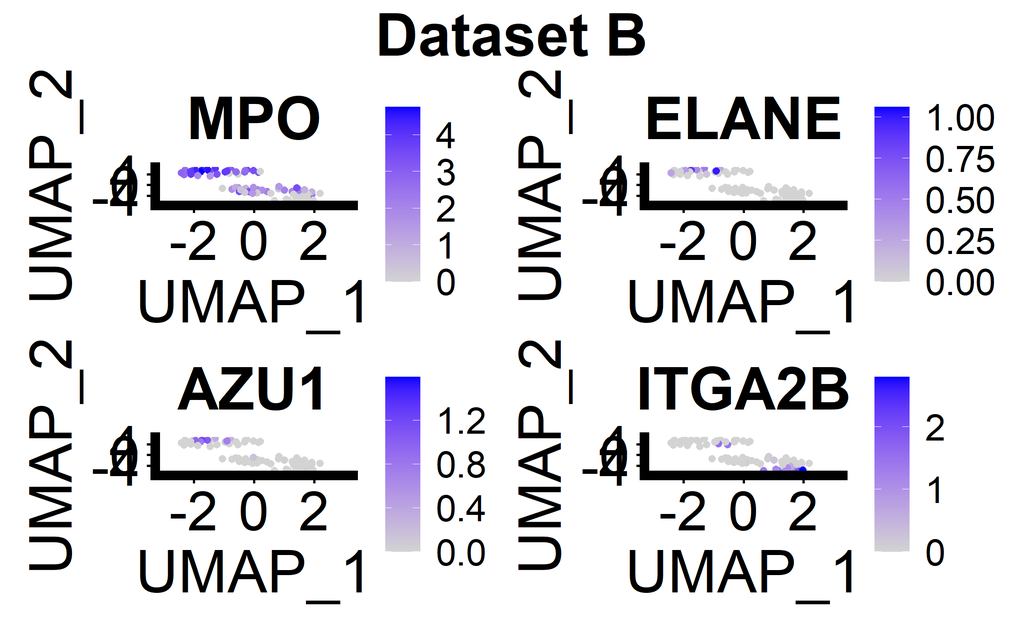

```r
fp_dtB
```

Save figures

```r
ggsave(fp_dtA,
       filename = "../Figures/Fig_genes_datasetA.svg",
       device = "svg",
       height = 9, width = 8, units = "in")
ggsave(fp_dtB,
       filename = "../Figures/Fig_genes_datasetB.svg",
       device = "svg",
       height = 6, width = 8, units = "in")
```

## Clustering with family label

```r
if (!"IIA9" %in% expB.realdata$family)
{expB.realdata@meta.data[expB.realdata$family %in% NA,]$family <- "IIA9"}
colors_family <- polychrome(30)
family_names <- sort(union(expA.realdata$family, expB.realdata$family))
df_cols <- data.frame(cbind(family_names, colors_family))
cols_dt1 <- df_cols[grepl("_", df_cols$family_names),"colors_family"]
cols_dt2 <- setdiff(unname(colors_family), cols_dt1)

family_dtA <-DimPlot(expA.realdata, group.by=c("family"),
reduction = 'umap_expA_sct', pt.size=3, order=T, cols=cols_dt1) + labs(title="Dataset A") + default_theme
```

|  | t | l | b | r |
| --- | --- | --- | --- | --- |
| 1: | 1 | 1 | 1 | 1 |

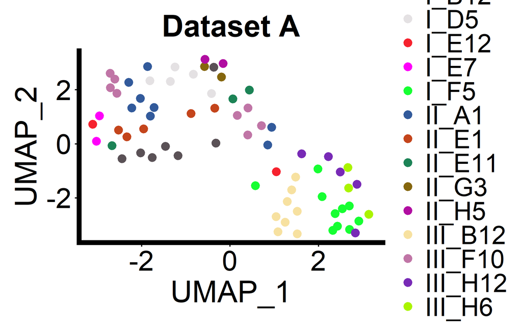

```r
family_dtA
```

```r
family_dtB <-DimPlot(expB.realdata, group.by=c("family"), reduction = 'umap_expB_sct', pt.size=3, order=T, cols= cols_dt2) +  labs(title="Dataset B") + default_theme
```

|  | t | l | b | r |
| --- | --- | --- | --- | --- |
| 1: | 1 | 1 | 1 | 1 |

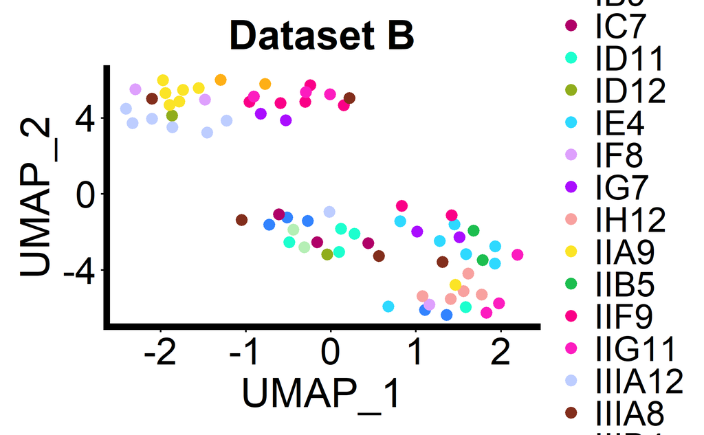

```r
family_dtB
```

Save figures

```r
ggsave(family_dtA,
       filename = "../Figures/Fig_familyUMAP_datasetA.svg",
       device = "svg",
       height = 6, width = 6.5, units = "in")
ggsave(family_dtB,
       filename = "../Figures/Fig_familyUMAP_datasetB.svg",
       device = "svg",
       height = 6, width = 6.5, units = "in")
```

## Violin plots for genes associated to families

```r
genes_to_plot <- c("CD84", "STAB1", "IGF2BP1", "IGLL1", "C1QTNF4", "SMIM24", "PRSS21",
"S100A9", "PAX8-AS1", "PSME2P6", "TRBC2", "CLEC11A", "CD36", "LAMB2")

vp_dtA<- VlnPlot(expA.realdata,  genes_to_plot,  stack = F, sort = F,
group.by = "family", combine=F, cols=cols_dt1)

vp_dtA_labeled <- lapply(vp_dtA, function(p) {
  apply_theme(p) +
  labs(x = "Family") + theme(legend.position = "none", axis.text = element_text(size = 20))
})

vp_dtB<- VlnPlot(expB.realdata,  genes_to_plot,  stack = F, sort = F,
group.by = "family", combine=F, cols=cols_dt2)

vp_dtB_labeled <- lapply(vp_dtB, function(p) {
  apply_theme(p) +
  labs(x = "Family") + theme(legend.position = "none", axis.text = element_text(size = 20))
})

#vp_dtA_labeled
```

Save figures

```r
for (i in seq_along(vp_dtA_labeled)) {
  gene_name <- genes_to_plot[i]
  ggsave(
    filename = paste0("../Figures/Fig_violin_datasetA_", gene_name, ".svg"),
    plot = vp_dtA_labeled[[i]],
    device = "svg",
    height = 6,
    width = 6.5,
    units = "in"
  )
}

for (i in seq_along(vp_dtB_labeled)) {
  gene_name <- genes_to_plot[i]
  ggsave(
    filename = paste0("../Figures/Fig_violin_datasetB_", gene_name, ".svg"),
    plot = vp_dtB_labeled[[i]],
    device = "svg",
    height = 6,
    width = 6.5,
    units = "in"
  )
}
```

## Times of division

```r
font_size_legend <- 16
expA.realdata$T1 <- as.numeric(as.character(expA.realdata$T1))
expA.realdata$avg_dT2 <- as.numeric(as.character(expA.realdata$avg_dT2))
expA.realdata$avg_dT3 <- as.numeric(as.character(expA.realdata$avg_dT3))

T1_dtA <- FeaturePlot(expA.realdata, features = "T1", reduction = "umap_expA_sct", pt.size = 3) + labs(title = "Dataset A", color = "T1") + default_theme + theme(legend.text = element_text(size = font_size_legend))
```

|  | t | l | b | r |
| --- | --- | --- | --- | --- |
| 1: | 1 | 1 | 1 | 1 |

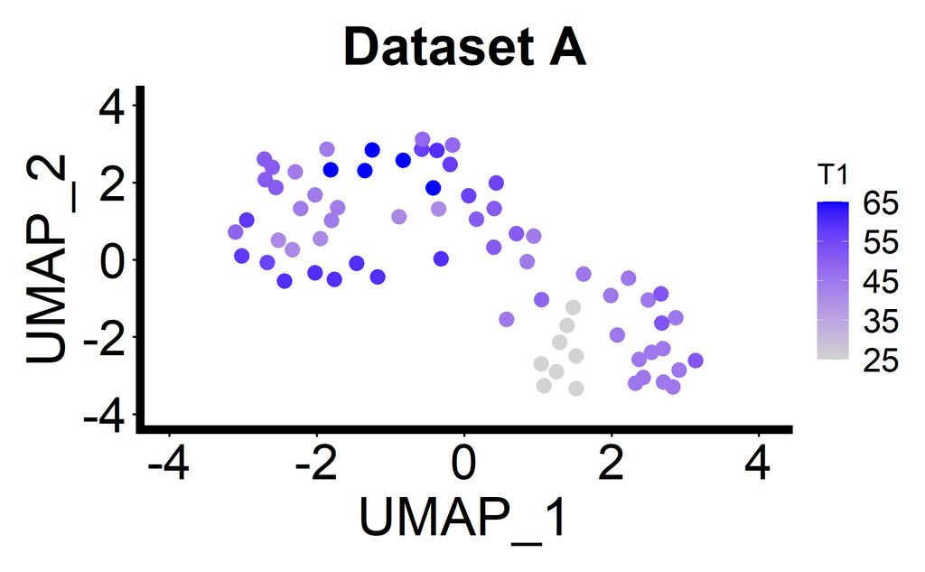

```r
T1_dtA
```

```r
T2_dtA <- FeaturePlot(expA.realdata, features = "avg_dT2", reduction = "umap_expA_sct", pt.size = 3) + labs(title = "Dataset A", color = "avg_dT2") + default_theme + theme(legend.text = element_text(size = font_size_legend))
```

|  | t | l | b | r |
| --- | --- | --- | --- | --- |
| 1: | 1 | 1 | 1 | 1 |

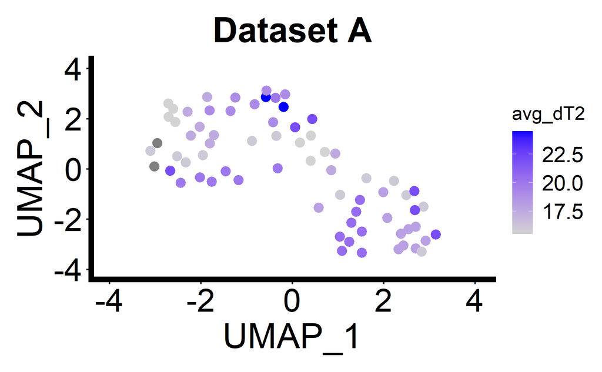

```r
T2_dtA
```

```r
T3_dtA <- FeaturePlot(expA.realdata, features = "avg_dT3", reduction = "umap_expA_sct", pt.size = 3) + labs(title = "Dataset A", color = "avg_dT3") + default_theme + theme(legend.text = element_text(size = font_size_legend))
```

|  | t | l | b | r |
| --- | --- | --- | --- | --- |
| 1: | 1 | 1 | 1 | 1 |

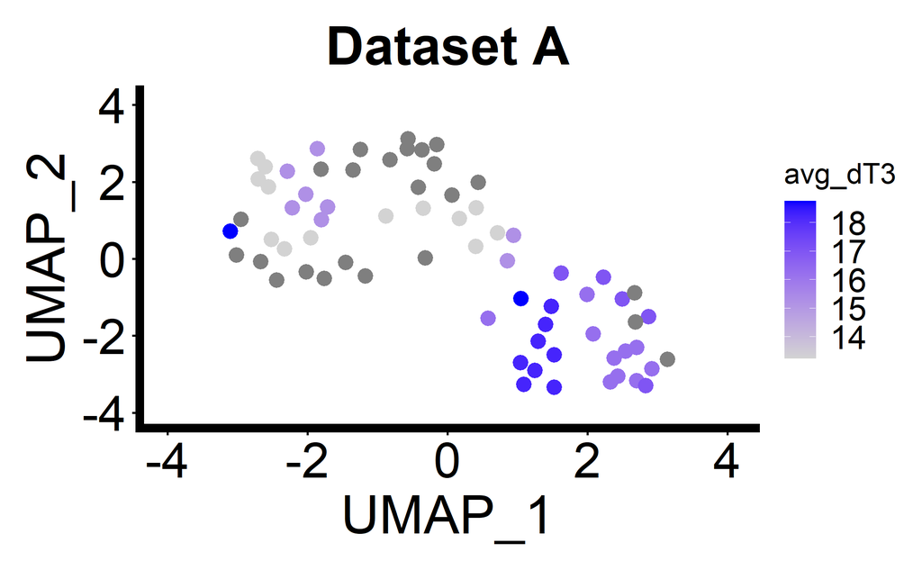

```r
T3_dtA
```

```r
expB.realdata$T1 <- as.numeric(as.character(expB.realdata$T1))
expB.realdata$avg_dT2 <- as.numeric(as.character(expB.realdata$avg_dT2))
expB.realdata$avg_dT3 <- as.numeric(as.character(expB.realdata$avg_dT3))

T1_dtB <- FeaturePlot(expB.realdata, features = "T1", reduction = "umap_expB_sct", pt.size = 3) + labs(title = "Dataset B", color = "T1") + default_theme + theme(legend.text = element_text(size = font_size_legend))
```

|  | t | l | b | r |
| --- | --- | --- | --- | --- |
| 1: | 1 | 1 | 1 | 1 |

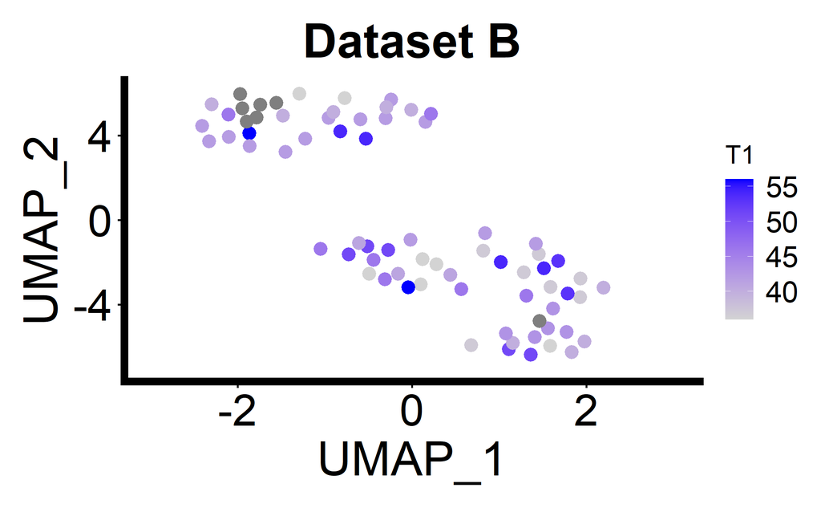

```r
T1_dtB
```

```r
T2_dtB <- FeaturePlot(expB.realdata, features = "avg_dT2", reduction = "umap_expB_sct", pt.size = 3) + labs(title = "Dataset B", color = "avg_dT2") + default_theme + theme(legend.text = element_text(size = font_size_legend))
```

|  | t | l | b | r |
| --- | --- | --- | --- | --- |
| 1: | 1 | 1 | 1 | 1 |

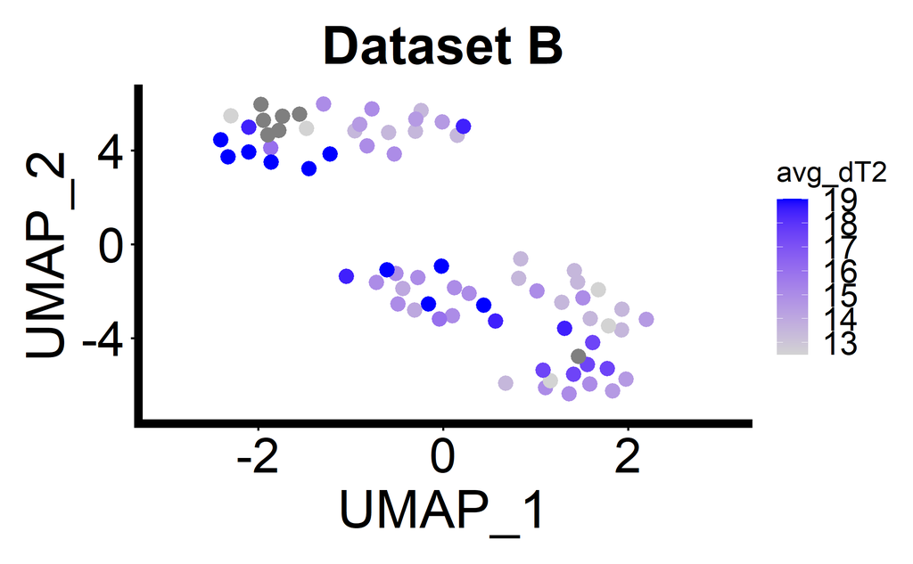

```r
T2_dtB
```

```r
T3_dtB <- FeaturePlot(expB.realdata, features = "avg_dT3", reduction = "umap_expB_sct", pt.size = 3) + labs(title = "Dataset B", color = "avg_dT3") + default_theme + theme(legend.text = element_text(size = font_size_legend))
```

|  | t | l | b | r |
| --- | --- | --- | --- | --- |
| 1: | 1 | 1 | 1 | 1 |

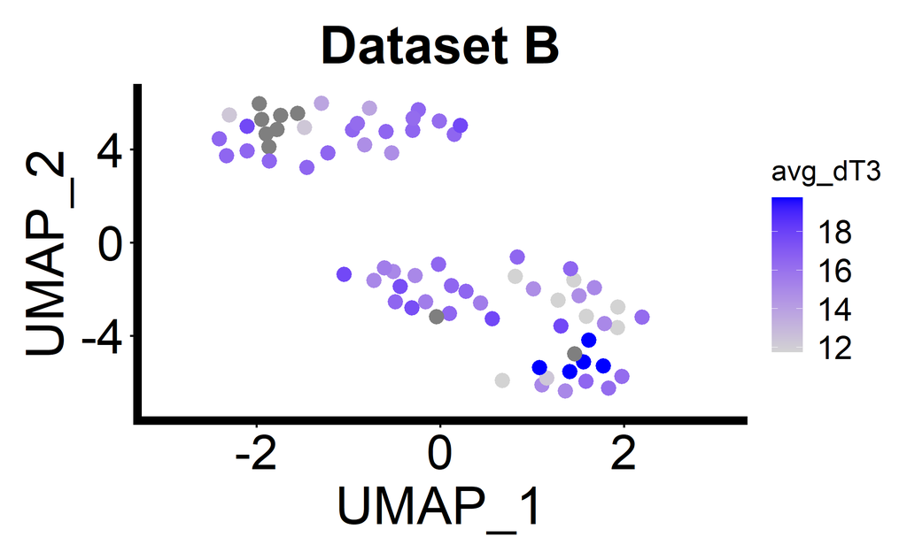

```r
T3_dtB
```

Save figures

```r
ggsave(T1_dtA,
       filename = "../Figures/Fig_T1_datasetA.svg",
       device = "svg",
       height = 6, width = 6.5, units = "in")
ggsave(T2_dtA,
       filename = "../Figures/Fig_avgdT2_datasetA.svg",
       device = "svg",
       height = 6, width = 6.5, units = "in")
ggsave(T3_dtA,
       filename = "../Figures/Fig_avgdT3_datasetA.svg",
       device = "svg",
       height = 6, width = 6.5, units = "in")
ggsave(T1_dtB,
       filename = "../Figures/Fig_T1_datasetB.svg",
       device = "svg",
       height = 6, width = 6.5, units = "in")
ggsave(T2_dtB,
       filename = "../Figures/Fig_avgdT2_datasetB.svg",
       device = "svg",
       height = 6, width = 6.5, units = "in")
ggsave(T3_dtB,
       filename = "../Figures/Fig_avgdT3_datasetB.svg",
       device = "svg",
       height = 6, width = 6.5, units = "in")
```

## Feature plot with log2 of colony size

```r
expA.realdata$Colony_size <- as.numeric(as.character(expA.realdata$Colony_size))
expA.realdata$Log2CS <- log2(expA.realdata$Colony_size)
logcs_dtA <- FeaturePlot(expA.realdata, features = "Log2CS", reduction = "umap_expA_sct", pt.size = 3) + labs(title = "Dataset A", color = "Log2CS") + default_theme + theme(legend.text = element_text(size = font_size_legend))
```

|  | t | l | b | r |
| --- | --- | --- | --- | --- |
| 1: | 1 | 1 | 1 | 1 |

```r
int_breaks <- c(2, 3, 4)
expB.realdata$Colony_size <- as.numeric(as.character(expB.realdata$Colony_size))
expB.realdata$Log2CS <- log2(expB.realdata$Colony_size)
logcs_dtB <- FeaturePlot(expB.realdata, features = "Log2CS", reduction = "umap_expB_sct", pt.size = 3) + labs(title = "Dataset B", color = "Log2CS") + default_theme + theme(legend.text = element_text(size = font_size_legend)) +  scale_color_gradient(
    low="lightgrey", high = "blue",
    breaks = int_breaks,
    labels = int_breaks
  )
```

|  | t | l | b | r |
| --- | --- | --- | --- | --- |
| 1: | 1 | 1 | 1 | 1 |

Save figures

```r
ggsave(logcs_dtA,
       filename = "../Figures/Fig_logcs_datasetA.svg",
       device = "svg",
       height = 6, width = 6.5, units = "in")
ggsave(logcs_dtB,
       filename = "../Figures/Fig_logcs_datasetB.svg",
       device = "svg",
       height = 6, width = 6.5, units = "in")
```

## Pseudotime analysis

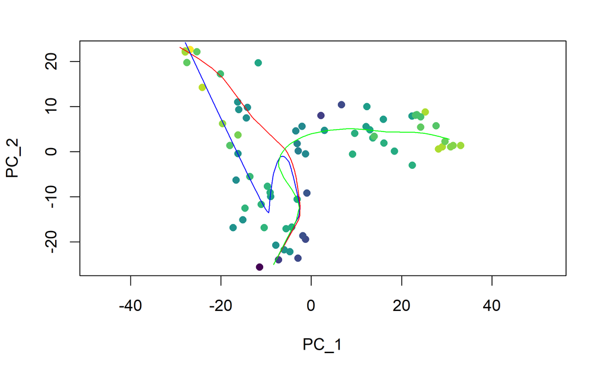

```r
library(slingshot)
library(ggbeeswarm)
library(ggthemes)

pseudotime_analysis <- function(
    seurat_slot,
    name_reduced_dim1,
    name_reduced_dim2,
    name_reduced_dim3,
    colors_fourclusters,
    PCAcomponents=15){

  # load experiment
  Seurat_object <- seurat_slot
  DefaultAssay(Seurat_object) <- "RNA"
  sce <- as.SingleCellExperiment(Seurat_object, assay="RNA")
  reducedDim(sce, name_reduced_dim1) <- reducedDim(sce, name_reduced_dim1)[, 1:PCAcomponents]
  # using PCA causa UMAP could distort the distances - PCA is linear
  # using a reduced numbe of components
  # slingshot inference
  sce_time <- slingshot(sce,
                        reducedDim = name_reduced_dim1,
                        clusterLabels = sce@colData$predicted.celltype,
                        start.clus = c("CD34+CD38-/HPC"),
                        #end.clus=c("GraP", "EryP/MkP")
  )
  #  collect all found lineages
  pseudotime_matrix <- slingPseudotime(sce_time)
  lineages <- colnames(pseudotime_matrix)
  for (lineage in lineages){
    Seurat_object[[paste0("slingshot_pseudotime_", lineage)]] <- pseudotime_matrix[, lineage]
  }

  # branch and slingshot_pseudotime assignment based on maximum pseudotime
  # this is particularly important for HPC cells, for which one pseudotime value for lineage is assigned
  Seurat_object$slingshot_branch <- apply(pseudotime_matrix, 1, function(x) {
    names(x)[which.max(x)]
  })
  Seurat_object$slingshot_pseudotime <- apply(pseudotime_matrix, 1, function(x) max(x, na.rm = TRUE))

  #Create pseudotime clusters (3) and plot: early, intermediate and late cells
  Seurat_object$slingshot_pseudotime_quantiles <- ntile(Seurat_object$slingshot_pseudotime, 3)
  umap_pseudotime_quantiles <- DimPlot(Seurat_object, group.by = "slingshot_pseudotime_quantiles",        pt.size=3)

  # Plot pca with pseudotime
  colors <- viridis::viridis(50)
  plot(reducedDims(sce_time)$PCA, col = colors[cut(Seurat_object$slingshot_pseudotime, breaks = 50)],     pch = 16, asp = 1)
  slingshot_lines <- SlingshotDataSet(sce_time)
  colors <- c("red", "blue", "green", "black", "yellow", "purple")
  n_curves <- length(slingshot_lines@curves)
  for (i in 1:n_curves) {
    lines(slingshot_lines@curves[[i]], col = colors[[i]])
  }
  pca_pseudo_lines <- recordPlot()
  # cell types on pca components
  pca_celltypes <- DimPlot(Seurat_object, reduction=name_reduced_dim2, cols=colors_fourclusters,
  pt.size=3, order=T) + ggtitle("Dataset A") + default_theme

  # Plot Slingshot pseudotime vs cell stage.
  df <- data.frame(
    pseudotime = Seurat_object$slingshot_pseudotime,
    branch = Seurat_object$slingshot_branch,
    cellfate = Seurat_object$predicted.celltype
  )
  cellfate_pseudotime <- ggplot(df, aes(x = pseudotime, y = cellfate, colour = branch)) +
    geom_quasirandom(groupOnX = FALSE) +
    scale_color_manual(values = c("Lineage1" = "red", "Lineage2" = "blue", "Lineage3"="green")) +
    theme_classic() +
    xlab("Slingshot pseudotime") + ylab("Cell type") +
    ggtitle("Cells ordered by Slingshot pseudotime and branch")
  # feature plot on umap - pseudotime
  umap_pseudotime <- FeaturePlot(Seurat_object, features = "slingshot_pseudotime", reduction =            name_reduced_dim3, pt.size = 3)+
    scale_color_gradient(low = "yellow", high = "red")

    # feature plot on - branch
  umap_branch <- DimPlot(Seurat_object, group.by = "slingshot_branch", reduction = name_reduced_dim3,   pt.size = 3)+
    scale_color_manual(values = c("Lineage1" = "red", "Lineage2" = "blue", "Lineage3" = "green"))

  output <- list("umap_pseudotime_quantiles"=umap_pseudotime_quantiles,
                 "umap_pseudotime"=umap_pseudotime,      "umap_branch"=umap_branch,
                 "cellfate_pseudotime"=cellfate_pseudotime,
                 "pca_pseudo_lines"=pca_pseudo_lines,
                 "pca_celltypes" = pca_celltypes,
                 "pseudotime_matrix" = pseudotime_matrix
                 )
  return(output)
}

# DatasetA
seurat_slot <- expA.realdata
name.rdim1 <- "PCA_EXPA_SCT"
name.rdim2 <- 'pca_expA_sct'
name.rdim3 <- "umap_expA_sct"
slingshot_A <- pseudotime_analysis(seurat_slot, name.rdim1, name.rdim2, name.rdim3, colors_fourclusters)
```

```r
pseudo_dtA <- slingshot_A[["umap_pseudotime"]] + labs(title = "Dataset A") + default_theme + theme(legend.text = element_text(size = font_size_legend))
```

|  | t | l | b | r |
| --- | --- | --- | --- | --- |
| 1: | 1 | 1 | 1 | 1 |

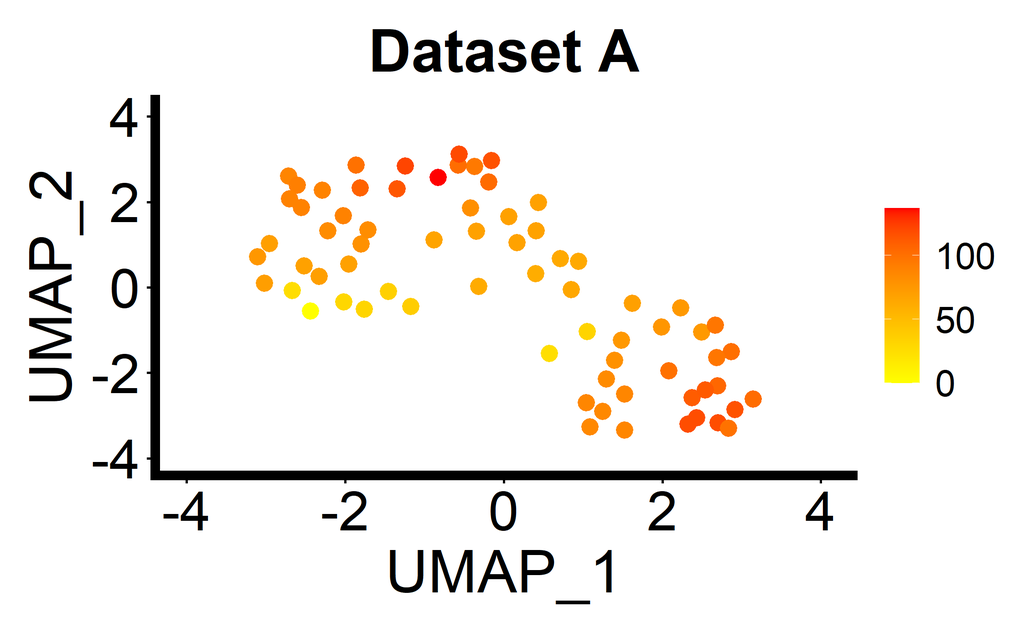

```r
pseudo_dtA
```

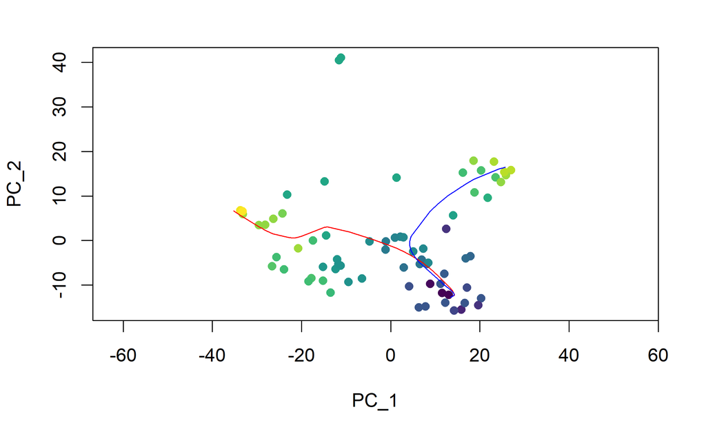

```r
# DatasetB
seurat_slot <- expB.realdata
name.rdim1 <- "PCA_EXPB_SCT"
name.rdim2 <- 'pca_expB_sct'
name.rdim3 <- "umap_expB_sct"
slingshot_B <- pseudotime_analysis(seurat_slot, name.rdim1, name.rdim2, name.rdim3, colors_fourclusters)
```

```r
pseudo_dtB <- slingshot_B[["umap_pseudotime"]] + labs(title = "DatasetB") + default_theme + theme(legend.text = element_text(size = font_size_legend))
```

|  | t | l | b | r |
| --- | --- | --- | --- | --- |
| 1: | 1 | 1 | 1 | 1 |

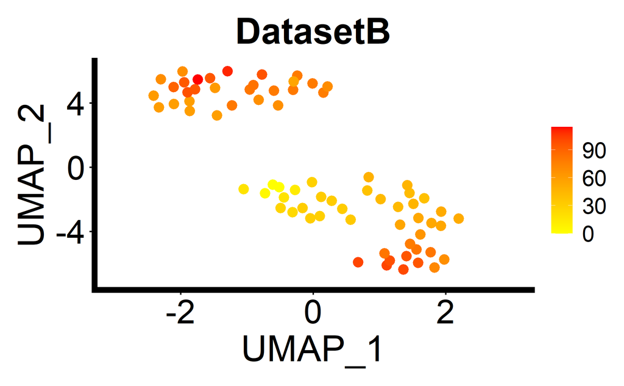

```r
pseudo_dtB
```

Save figures

```r
ggsave(pseudo_dtA,
       filename = "../Figures/Fig_pseudotime_datasetA.svg",
       device = "svg",
       height = 6, width = 6.5, units = "in")
ggsave(pseudo_dtB,
       filename = "../Figures/Fig_pseudotime_datasetB.svg",
       device = "svg",
       height = 6, width = 6.5, units = "in")
```

Scores for lineages

```r
plot_scores_for_lineage <- function(mat){

df <- as.data.frame(mat)
df_filtered <- df[rowSums(!is.na(df)) > 1, ]
df_filtered$sample <- rownames(df_filtered)

df_long <- df_filtered %>%
  pivot_longer(
    cols = -sample,
    names_to = "score_type",
    values_to = "value"
  )

df_long <- df_long %>%
  group_by(sample) %>%
  mutate(value = value / sum(value))

plot_pie <- ggplot(df_long, aes(x = "", y = value, fill = score_type)) +
  geom_bar(stat = "identity", width = 1) +
  coord_polar("y") +
  facet_wrap(~ sample) +
  theme_void() +
  theme(legend.position = "bottom")
return(plot_pie)}

pie_dtA <- plot_scores_for_lineage(slingshot_A$pseudotime_matrix)
pie_dtB <- plot_scores_for_lineage(slingshot_B$pseudotime_matrix)
```